# Party Polarization Analysis

Raghav Chegu Shyam Kumar

4/5/2022

#### **Introduction:**

In this project, we examine the ideological differences between the two major political parties in the United States, the Democratic Party and the Republican Party, to understand the polarization effect over time. This is achieved by examining how senators from both parties voted on bills each year from 1989 to 2014.

#### **Polarization in two years:**

Initially, we look for the differences between the members and vote data for 1989 and 2014 to determine the changes in the two years. This is achieved by applying the MDS on the data and analyzing for the same.

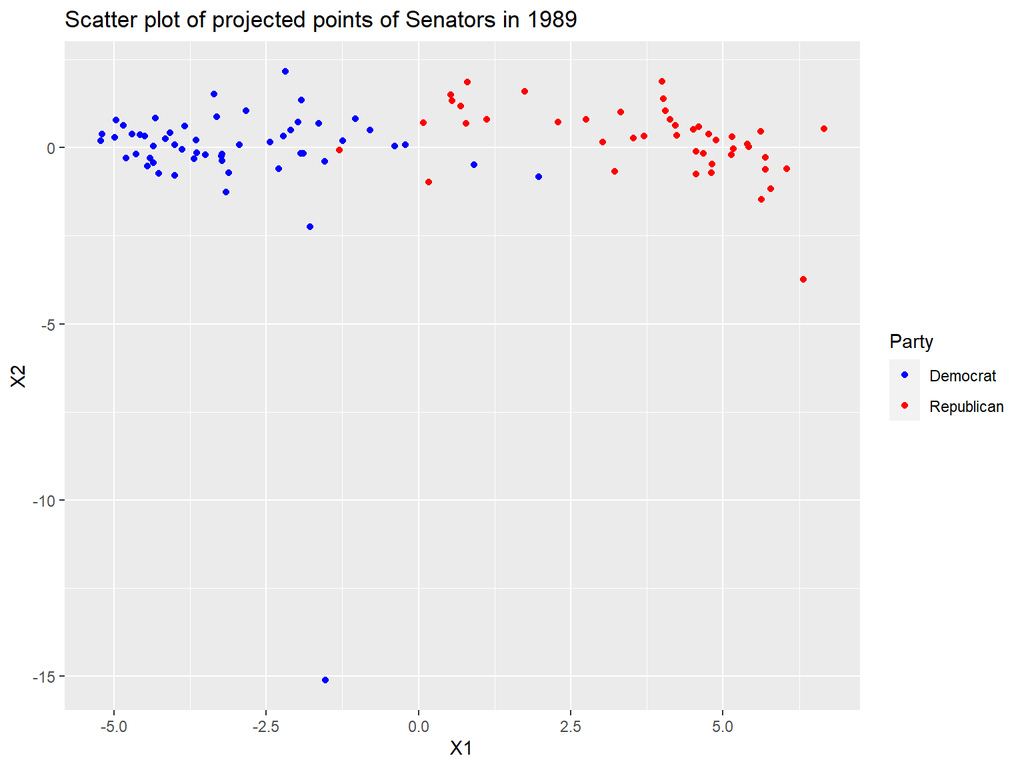

**Observations - 1989:**

- We can observe from the above graph, the Republican and Democratic parties do not have a singular point of view on the bills in 1989 with the Democratic Party in blue and the Republican Party in red.
- This can be observed by the spread of the points in the cluster of both parties.
- The difference between the two clusters is more pronounced along X1 than X2, indicating that they are separated by a one-dimensional liberal/conservative axis.
- There aren’t many outliers in this sample. There is only one point that deviates significantly from the distribution.

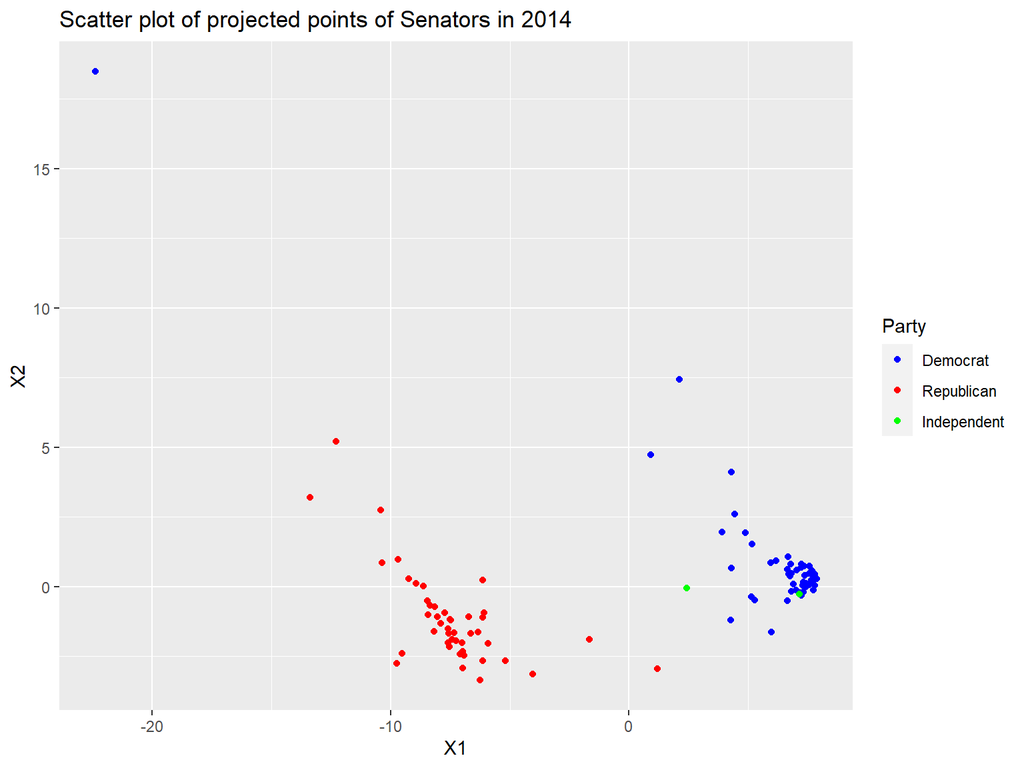

**Observations - 2014:**

- The above graph shows that the Republican and Democratic parties are establishing distinct clusters suggesting that both parties have grown more ideologically cohesive in 2014.
- This can be observed by the low spread of the points in the cluster of both parties.
- The difference between the two clusters is more pronounced along X1 than X2, indicating that they are separated by a one-dimensional liberal/conservative axis.
- There aren’t many outliers in this sample. There are only two-three points that deviates significantly from the distribution.

**Pattern Similarity:**

**Comparison of PCA and MDS:**

- It can observed that the graphs between PCA and MDS is similar especially in the 1989 graph.
- The 2014 graph for PCA and MDS portray similarity on the cluster formation although the principal component values vary.
- The PCA graphs are added in the appendix.

#### **Polarization over time:**

In the following analysis, we look for the change in polarization over time. This is achieved by applying MDS on the data and using the centroids, calculate the extent of the polarization if observed.

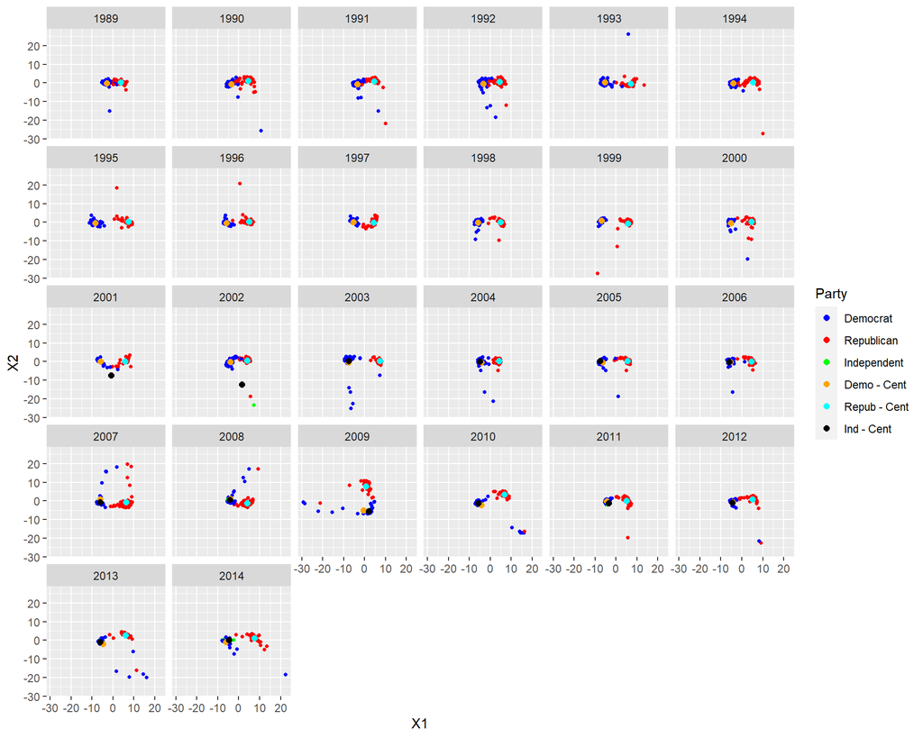

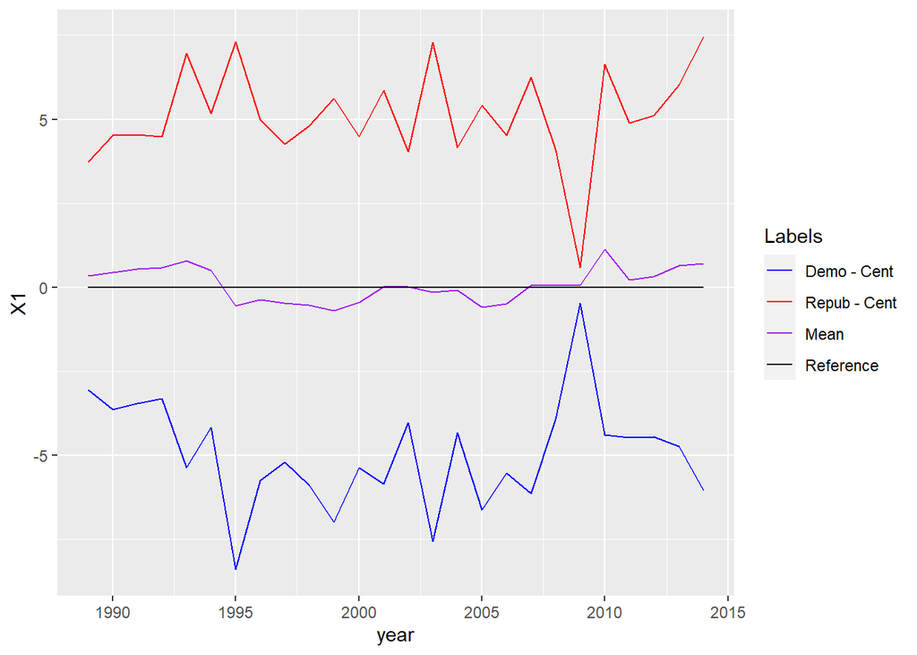

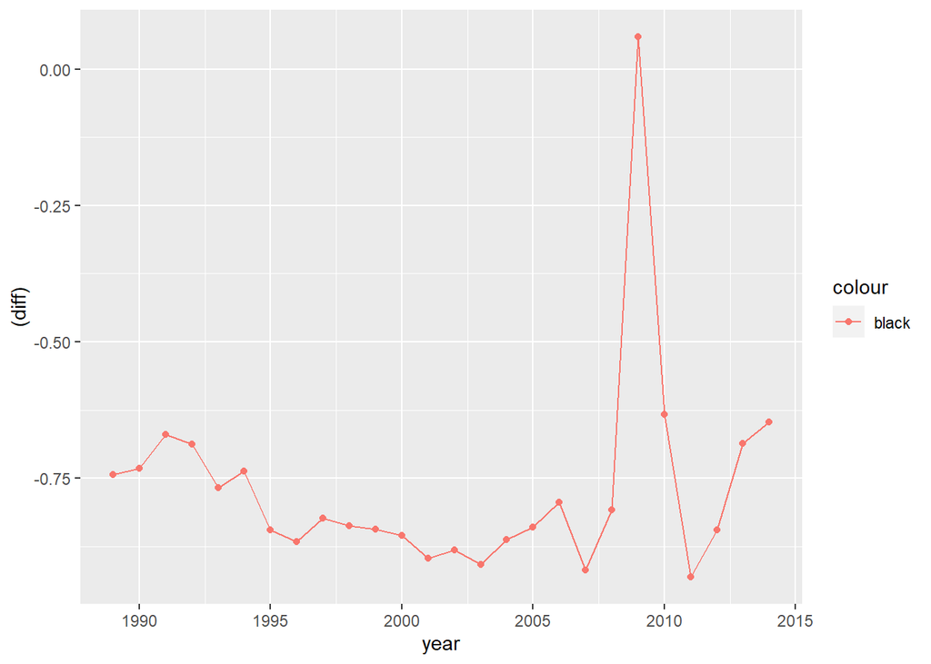

**Measure for polarization:** The measure being used here to detect the polarization over time is the centroid for the clusters taking the mean. These mean centroids show how the senators from the parties are getting clustered, hence, understanding the polarization effect over time.

**Polarization over time:** Yes, there has been a rise in polarization throughout time. Since we’ve been computing the mean centroids, we’ve noticed that the differences between each centroid are widening, implying that the polarization is increasing over time.

**Is something more complicated happening?** Yes, it can be observed that there are complications which can be seen below:

### **Ideological position of one senator:**

```r
john <- df_mds %>% subset(id=="S197")
mitch <- df_mds %>% subset(id=='S174')
john_p <- df_pca %>% subset(id=="S197")
mitch_p <- df_pca %>% subset(id=='S174')
df_mds_j <- df_mds %>% subset(!id=="S197")
df_mds_m <- df_mds %>% subset(!id=="S174")
```

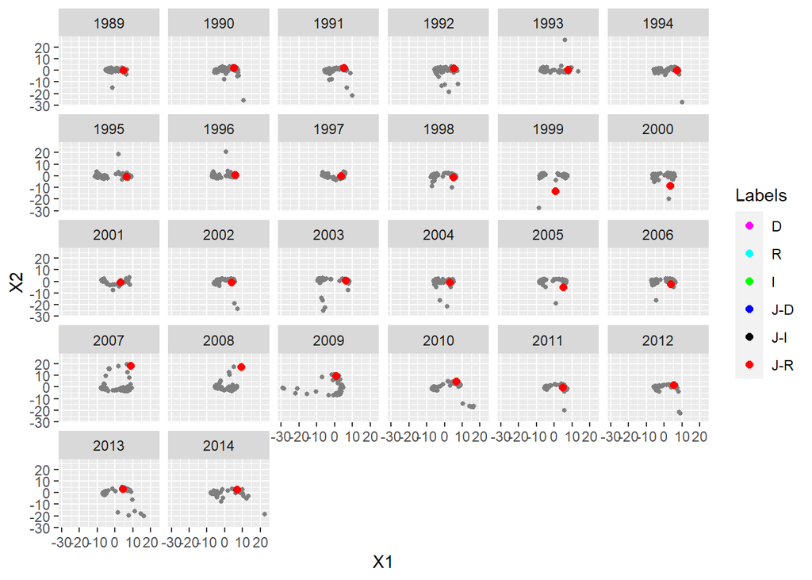

```r
john[john$party=="Democrat",3] <- "J-D"
john[john$party=="Independent",3] <- "J-I"
john[john$party=="Republican",3] <- "J-R"
ggplot(df_mds_j, aes(x=X1, y=X2, color = party)) +
  geom_point(size=1)+ geom_point(data=john,size=2, aes(color = party)) + facet_wrap(~year) + scale_color_manual(name = "Labels", values = c("D" = "magenta", "R" = "cyan", "I" = "green", "J-D" = "blue", "J-I" = "black", "J-R" = "red"))
```

```r
#john_p[john_p$party=="D",3] <- "J-D"
#john_p[john_p$party=="I",3] <- "J-I"
#john_p[john_p$party=="R",3] <- "J-R"
#mitch_p[mitch_p$party=="D",3] <- "M-D"
#mitch_p[mitch_p$party=="I",3] <- "M-I"
#mitch_p[mitch_p$party=="R",3] <- "M-R"
#ggplot(centroids_pca, aes(x=year, y=PC1, color = party)) +
  #geom_point(size=3) +
#  geom_line() + geom_line(data=john_p, aes(color = party)) + geom_line(data=mitch_p, aes(color = party)) + scale_color_manual(name = "Labels", values = c("D1" = "blue", "R1" = "red", "I1" = "green", "J-R" = "black", "M-R" = "purple"))
```

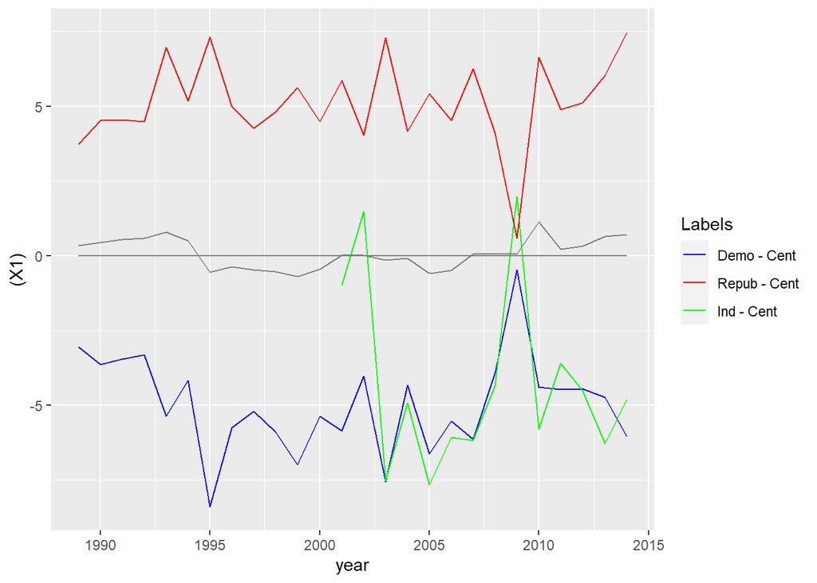

```r
ggplot(centroids_mds, aes(x=year, y=(X1), color = party)) +
  #geom_point(size=3) +
  geom_line() + scale_color_manual(name = "Labels", values = c("Demo - Cent" = "blue", "Repub - Cent" = "red", "Ind - Cent" = "green"))
```

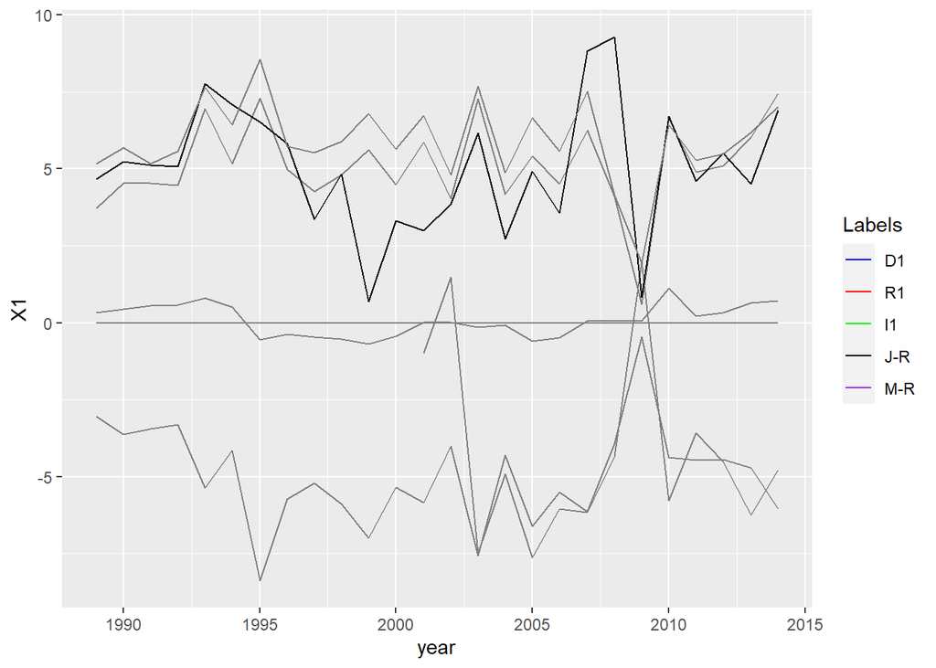

```r
john[john$party=="D",3] <- "J-D"
john[john$party=="I",3] <- "J-I"
john[john$party=="R",3] <- "J-R"
mitch[mitch$party=="D",3] <- "M-D"
mitch[mitch$party=="I",3] <- "M-I"
mitch[mitch$party=="R",3] <- "M-R"
ggplot(centroids_mds, aes(x=year, y=X1, color = party)) +
  #geom_point(size=3) +
  geom_line() + geom_line(data=john, aes(color = party)) + geom_line(data=mitch, aes(color = party)) + scale_color_manual(name = "Labels", values = c("D1" = "blue", "R1" = "red", "I1" = "green", "J-R" = "black", "M-R" = "purple"))
```

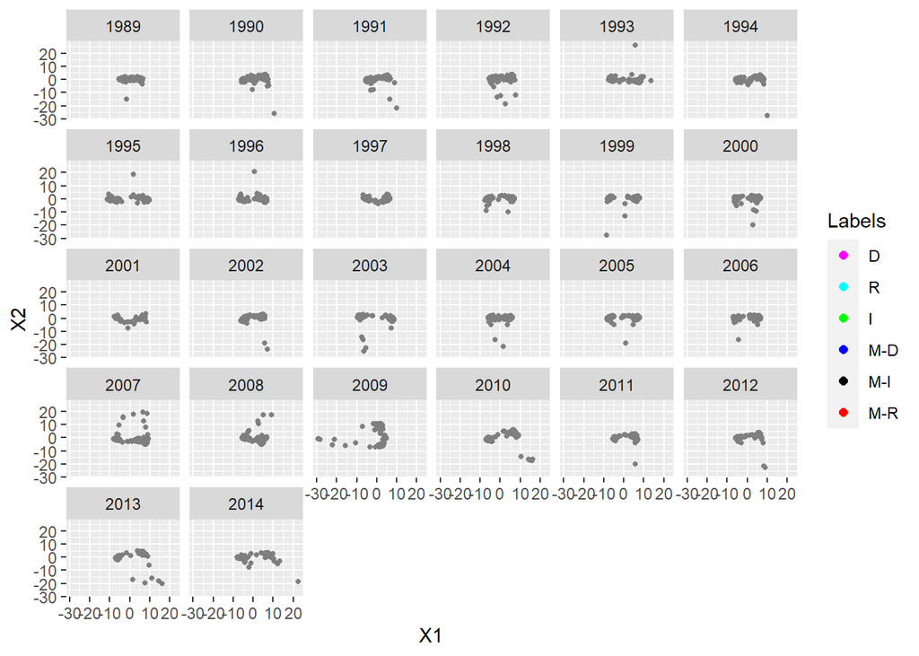

```r
mitch[mitch$party=="D",3] <- "M-D"
mitch[mitch$party=="I",3] <- "M-I"
mitch[mitch$party=="R",3] <- "M-R"
ggplot(df_mds_m, aes(x=X1, y=X2, color = party)) +
  geom_point(size=1)+ geom_point(data=mitch,size=2, aes(color = party)) + facet_wrap(~year) + scale_color_manual(name = "Labels", values = c("D" = "magenta", "R" = "cyan", "I" = "green", "M-D" = "blue", "M-I" = "black", "M-R" = "red"))
```

#### **Appendix:**

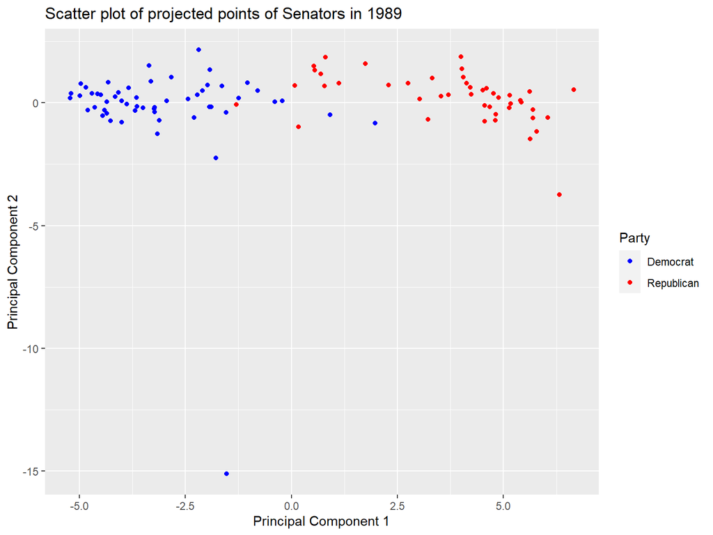

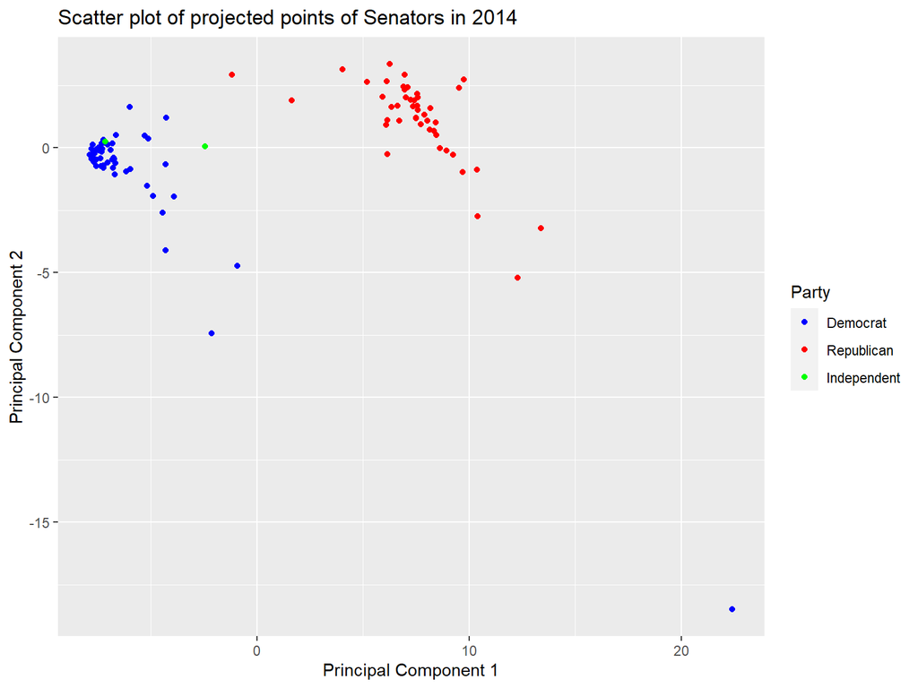

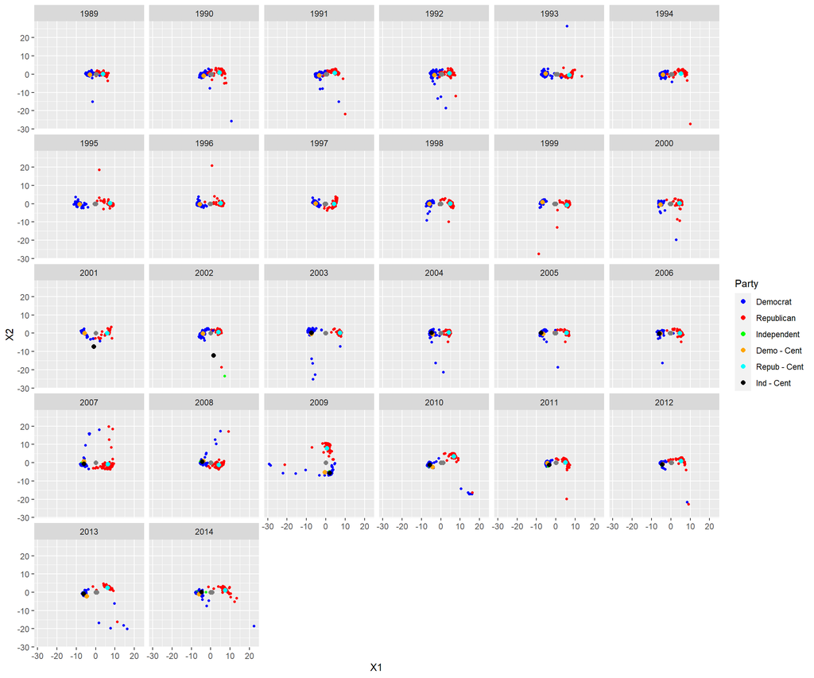